# Northern Rockfish

*Sebastes polyspinis*

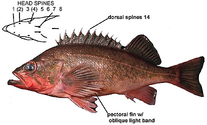

**Body color:** Dark gray-green on reddish background; red-orange flecks and fine green spots on body; red-orange to white ventrally; oblique light band on lower portion of pectoral fin.

**Peritoneum color:** dark **Shape between eyes:** convex

**Counts:** D:XIV,13-16, Ar:7-9, P1:17-19, GR:35-39, LLp:43-53, LLs:69-70, V:28

**Occurence:** Bering Sea - British Columbia

**Depth:** 625 meters **Size:** 40 cm **Species code:** 30420

**Similar species:**

- *Dusky (light) rockfish* - body gray to greenish-brown; light patch on pectoral fin faint; dorsal spines typically 13
- *Pacific Ocean Perch* - body red w/ discrete dorsal blotches; symphyseal knob sharp, elongate (moderate in Northern RF); head spine 5 present; dorsal spines typically 13
- *Redstripe rockfish* - mottled olive-green stripes above and below light red lateral line; head spine count differs; dorsal spines typically 13; head spine 5 present
- *Harlequin rockfish* - head spines strong and spine 5 is present; anal spine 2 longer than 3 (shorter in Northern RF); dorsal blotches prominent; posterior 2/3 of lateral line light; dorsal spines typically 13
- *Sharpchin rockfish* - body red w/ dorsal blotches; head spines strong and differ in count; anal spine 2 longer than 3; dorsal spines typically 13

Back to Group

**Corrections:** If you see mistakes or want to suggest changes, please create an [issue](https://github.com/zoyafuso-NOAA/RACE_Survey_App/issues) on the source repository or

*reach out to Liz Dawson (Liz.Dawson AT noaa.gov).*